# Practical Machine Learning

Sim Chee Yuong

26 December 2015

## Introduction

Using devices such as Jawbone Up, Nike FuelBand, and Fitbit it is now possible to collect a large amount of data about personal activity relatively inexpensively. These type of devices are part of the quantified self movement - a group of enthusiasts who take measurements about themselves regularly to improve their health, to find patterns in their behavior, or because they are tech geeks. One thing that people regularly do is quantify how much of a particular activity they do, but they rarely quantify how well they do it. In this project, your goal will be to use data from accelerometers on the belt, forearm, arm, and dumbell of 6 participants. They were asked to perform barbell lifts correctly and incorrectly in 5 different ways. More information is available from the website here: http://groupware.les.inf.puc-rio.br/har (see the section on the Weight Lifting Exercise Dataset).

## Sources

The training data and testing data for this project are available here:

1. Training data https://d396qusza40orc.cloudfront.net/predmachlearn/pml-training.csv
2. Testing data https://d396qusza40orc.cloudfront.net/predmachlearn/pml-testing.csv

The data for this project come from this source: http://groupware.les.inf.puc-rio.br/har.

## Objective

Our objective is to predict the manner in which they did the exercise. We use classe variable in the training set to complete our prediction. The processes of building the model in this project involve getting and cleaning the data, features selection, algorithm consideration and parameters selection to complete the evaluation. This report may include the types of model to be built, the process of cross validation, the expected out of sample error with a conclusion for the report.

### Data Processing

First, setup the directory and libraries.

```r
setwd('C:/Users/user/Desktop/Project')
library(caret)
library(randomForest)
library(rpart)
library(rpart.plot)
library(rattle)
```

#### Getting and reading the data

```r
training <- read.csv(file="pml-training.csv", header=TRUE,
                     sep=",", na.strings = c("NA","#DIV/0!",""))
testing <- read.csv(file="pml-testing.csv",header=TRUE,
                    sep=",", na.strings = c("NA","#DIV/0!",""))

names(training)
```

```
##   [1] "X"                        "user_name"
##   [3] "raw_timestamp_part_1"     "raw_timestamp_part_2"
##   [5] "cvtd_timestamp"           "new_window"
##   [7] "num_window"               "roll_belt"
##   [9] "pitch_belt"               "yaw_belt"
##  [11] "total_accel_belt"         "kurtosis_roll_belt"
##  [13] "kurtosis_picth_belt"      "kurtosis_yaw_belt"
##  [15] "skewness_roll_belt"       "skewness_roll_belt.1"
##  [17] "skewness_yaw_belt"        "max_roll_belt"
##  [19] "max_picth_belt"           "max_yaw_belt"
##  [21] "min_roll_belt"            "min_pitch_belt"
##  [23] "min_yaw_belt"             "amplitude_roll_belt"
##  [25] "amplitude_pitch_belt"     "amplitude_yaw_belt"
##  [27] "var_total_accel_belt"     "avg_roll_belt"
##  [29] "stddev_roll_belt"         "var_roll_belt"
```

[output cut: 65 more lines]

```r
str(training)
```

[output not shown]

[output cut: 86 more lines]

```r
summary(training)
```

[output not shown]

[output cut: 313 more lines]

[output not shown]

```r
summary(training$classe)
```

```
##    A    B    C    D    E
## 5580 3797 3422 3216 3607
```

There are 19622 rows and 20 rows in the original training and testing data respectively with 160 columns in both data.

```r
dim(training);dim(testing)
```

```
## [1] 19622   160
```

```
## [1]  20 160
```

#### Cleaning data

Remove the missing values in the data and removing unrelated column.

```r
mv_training <- is.na(training)
mv_testing<-is.na(testing)
training <- training[,colSums(mv_training)==0]
testing <- testing[,colSums(mv_testing)==0]

training<-training[c(-(1:7))]
testing<-testing[c(-(1:7))]
```

The training and testing data sets have 53 columns.

```r
dim(training);dim(testing)
```

```
## [1] 19622    53
```

```
## [1] 20 53
```

#### Data Slicing

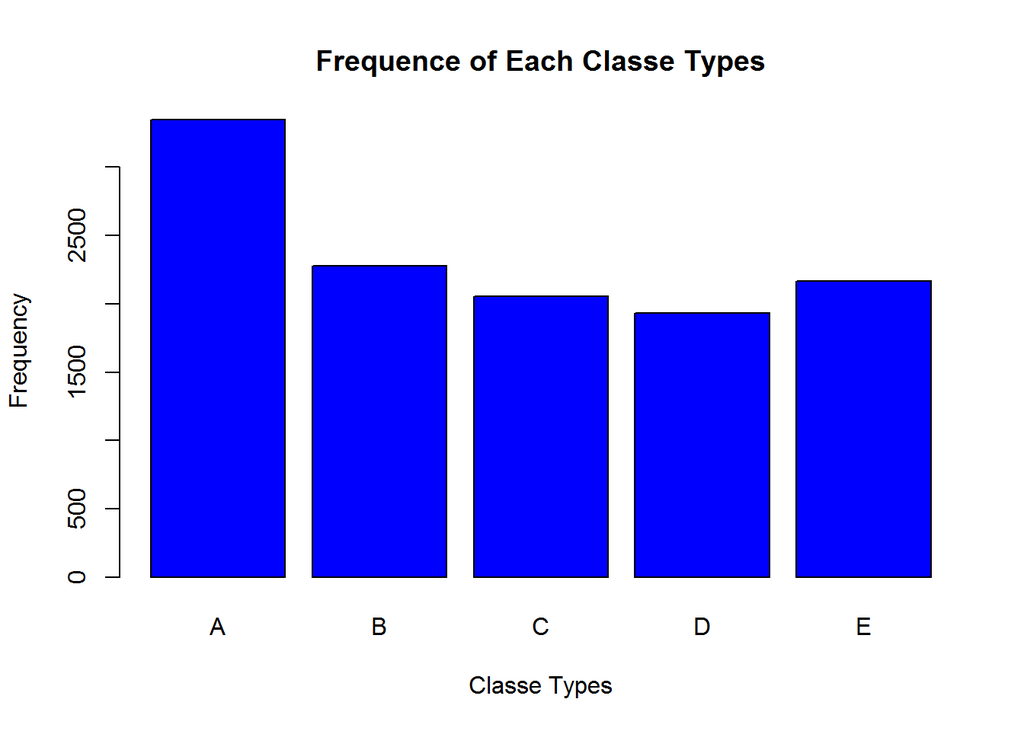

```r
set.seed(281215)
inTrain <- createDataPartition(y=training$classe,p=0.6,list=FALSE)
trainingSet <- training[inTrain,]
testingSet <- training[-inTrain,]
plot(trainingSet$classe,col="blue", xlab="Classe Types",
     ylab="Frequency", main = "Frequence of Each Classe Types")
```

The classe variable contains 5 types to perform barbell lifts.

### Machine Learning Algorithm for Prediction Process with:

#### 1) Decision Trees

```r
modDT<-train(classe ~ ., data = trainingSet,method="rpart")
print(modDT$finalModel)
```

```
## n= 11776
##
## node), split, n, loss, yval, (yprob)
##       * denotes terminal node
##
##  1) root 11776 8428 A (0.28 0.19 0.17 0.16 0.18)
##    2) roll_belt< 130.5 10812 7472 A (0.31 0.21 0.19 0.18 0.11)
##      4) pitch_forearm< -34.15 921    7 A (0.99 0.0076 0 0 0) *
##      5) pitch_forearm>=-34.15 9891 7465 A (0.25 0.23 0.21 0.2 0.12)
##       10) magnet_dumbbell_y< 439.5 8366 5993 A (0.28 0.18 0.24 0.19 0.11)
##         20) roll_forearm< 121.5 5168 3047 A (0.41 0.18 0.18 0.16 0.062) *
##         21) roll_forearm>=121.5 3198 2156 C (0.079 0.18 0.33 0.23 0.18) *
##       11) magnet_dumbbell_y>=439.5 1525  759 B (0.035 0.5 0.042 0.23 0.19) *
##    3) roll_belt>=130.5 964    8 E (0.0083 0 0 0 0.99) *
```

[figure not shown]

```r
#Decision Trees with fancy run command:
fancyRpartPlot(modDT$finalModel,main="Classification Tree")
```

```r
#Prediction on training data
predictionDT <-predict(modDT,newdata=testingSet)

confusionMatrix(predictionDT,testingSet$classe)
```

```
## Confusion Matrix and Statistics
##
##           Reference
## Prediction    A    B    C    D    E
##          A 2030  621  636  575  199
##          B   28  520   44  223  189
##          C  168  377  688  488  379
##          D    0    0    0    0    0
##          E    6    0    0    0  675
##
## Overall Statistics
##
##                Accuracy : 0.4987
##                  95% CI : (0.4876, 0.5099)
##     No Information Rate : 0.2845
##     P-Value [Acc > NIR] : < 2.2e-16
##
##                   Kappa : 0.3451
##  Mcnemar's Test P-Value : NA
##
## Statistics by Class:
##
##                      Class: A Class: B Class: C Class: D Class: E
## Sensitivity            0.9095  0.34256  0.50292   0.0000  0.46810
## Specificity            0.6382  0.92351  0.78203   1.0000  0.99906
## Pos Pred Value         0.4999  0.51793  0.32762      NaN  0.99119
## Neg Pred Value         0.9466  0.85414  0.88166   0.8361  0.89295
## Prevalence             0.2845  0.19347  0.17436   0.1639  0.18379
## Detection Rate         0.2587  0.06628  0.08769   0.0000  0.08603
## Detection Prevalence   0.5176  0.12796  0.26765   0.0000  0.08680
## Balanced Accuracy      0.7739  0.63304  0.64248   0.5000  0.73358
```

#### 2) Random Forest

```r
modFit<-train(classe ~ .,data=trainingSet, method="rf", trControl=trainControl(method='cv'), number=5,allowParallel=TRUE)

modFit
```

```
## Random Forest
##
## 11776 samples
##    52 predictor
##     5 classes: 'A', 'B', 'C', 'D', 'E'
##
## No pre-processing
## Resampling: Cross-Validated (10 fold)
## Summary of sample sizes: 10598, 10599, 10599, 10599, 10598, 10598, ...
## Resampling results across tuning parameters:
##
##   mtry  Accuracy   Kappa      Accuracy SD  Kappa SD
##    2    0.9911680  0.9888265  0.003541552  0.004481729
##   27    0.9898945  0.9872156  0.002578791  0.003263909
##   52    0.9868372  0.9833473  0.004186761  0.005298040
##
## Accuracy was used to select the optimal model using  the largest value.
## The final value used for the model was mtry = 2.
```

```r
predictionRF <-predict(modFit,testingSet)

getTree(modFit$finalModel,k=2)
```

[output not shown]

[output cut: 2509 more lines]

```r
predictionRF<-predict(modFit,newdata=testingSet)

confusionMatrix(predictionRF,testingSet$classe)
```

```
## Confusion Matrix and Statistics
##
##           Reference
## Prediction    A    B    C    D    E
##          A 2230   20    0    0    0
##          B    2 1492   16    0    0
##          C    0    6 1348   24    2
##          D    0    0    4 1262    4
##          E    0    0    0    0 1436
##
## Overall Statistics
##
##                Accuracy : 0.9901
##                  95% CI : (0.9876, 0.9921)
##     No Information Rate : 0.2845
##     P-Value [Acc > NIR] : < 2.2e-16
##
##                   Kappa : 0.9874
##  Mcnemar's Test P-Value : NA
##
## Statistics by Class:
##
##                      Class: A Class: B Class: C Class: D Class: E
## Sensitivity            0.9991   0.9829   0.9854   0.9813   0.9958
## Specificity            0.9964   0.9972   0.9951   0.9988   1.0000
## Pos Pred Value         0.9911   0.9881   0.9768   0.9937   1.0000
## Neg Pred Value         0.9996   0.9959   0.9969   0.9964   0.9991
## Prevalence             0.2845   0.1935   0.1744   0.1639   0.1838
## Detection Rate         0.2842   0.1902   0.1718   0.1608   0.1830
## Detection Prevalence   0.2868   0.1925   0.1759   0.1619   0.1830
## Balanced Accuracy      0.9978   0.9900   0.9902   0.9901   0.9979
```

The result above has been clearly shown that the random forest algorithm has performed better than the decision trees. The accuracy for the random forest model is stated with a percentage of 99.01% for cross-validation dataset with a 95% confidence interval in between 0.9876 and 0.9921. The expected out of sample error rate is 0.99% (1-99.01%). Hence, we can conclude that random forest algorithm can be used to build the model in this report.

#### Prediction on real testing data set.

```r
pred_testing <- predict(modFit, newdata=testing)
pred_testing
```

```
##  [1] B A B A A E D B A A B C B A E E A B B B
## Levels: A B C D E
```

```r
answers <- as.vector(pred_testing)

#Function to generate prediction files for submission.
write_files = function(x){
        n = length(x)
        for(i in 1:20){
                filename = paste0("problem_id_", i, ".txt")
                write.table(x[i], file=filename, quote=FALSE,
                            row.names=FALSE, col.names=FALSE)
        }
}
write_files(pred_testing)
```